# PARTS paramter estimation

Clay Morrow

5/18/2021

```r
library(ggplot2); library(dplyr)
theme_set(theme_classic() + theme(strip.background = element_blank()))
```

## Intro

This document will describe how PARTS estimates parameters of simulated data.

The “Code” boxes on the right hand side of the page can be clicked on the HTML version of this document to display code chunks used to create output.

## Data simulation

For simplicity, data in this document were modeled to include only effects of time and space:

$$X(t) = \lambda \times \text{latitude} + (\alpha + \beta \times \text{latitude})t + \varepsilon(t)$$

$\lambda = 0.1$ is the base effect of latitude (y coordinates) on $X$, $\alpha = 0.2$ is an intercept effect of time on $X$, and $\beta = 0.4$ is the interaction effect between latitude and time on $X$. Data are simulated for 20 time steps (i.e. $t = 1, 2, ..., 20$).

$\varepsilon$ is generated with an AR(1) process with spatially auto-correlated innovations. The AR parameter is fixed at 0.50.

All parameter values were selected to accentuate differences in $X$ across space and time.

```r
# FULL MODEL: X(t) = lambda*lat + (a + (beta * lat) )*t + e(t)

# 1) Starting (true) values ----
## map size
map.cols = map.rows = 20

## total number of pixels
npix = map.cols * map.rows

## total number of time points
ntime = 20

## time coefficient (intercept)
alpha = .2

## effect of latitude the time trend
beta = .4

lambda = .1

## pixel coordinates
coords = scales::rescale(as.matrix(expand.grid(x = as.double(1:map.cols),
                               y = as.double(1:map.rows))), to = c(0, 1))

## Distance between pixels (scaled between 0 and 1)
D <- scales::rescale(as.matrix(dist(coords)), to = c(0, 1))

## spatial correlation range parameter
r = .25 # 25% the width of the map

## nugget
nug = .10 #

## diagonal nugget matrix
nugmat = diag(rep(nug, npix))
# nugmat[1:5, 1:5] # visualize first 5 rows and cols
```

The spatial errors ($\delta$) are simulated with the exponential covariance function $exp(-d/r)$. $d = [0, 1]$ is the distance between points and $r = .25$ is the range of spatial auto-correlation.

This is what the covariance function looks like between 0 and 1:

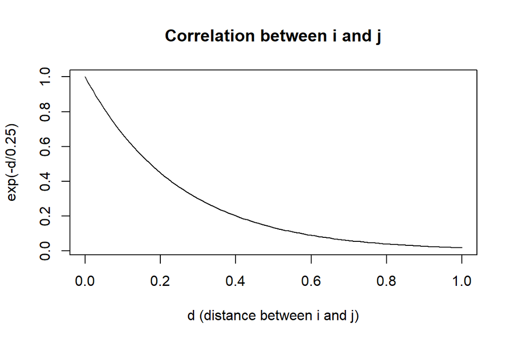

```r
# 2) Spatial Covariance ----

## exponential covariance function
covar_func <- function(d, range = r){
  covar = exp(-d/range) # exponential covariance function
  return(covar)
}

## Visualize the exponential covariance function
curve(covar_func(x), from = 0, to = 1,
      xlab = "d (distance between i and j)",
      ylab = paste0("exp(-d/",r, ")"),
      main = "Correlation between i and j")
```

To create the spatial covariance matrix, the results of this function are  
scaled by a nugget component ($1 - \eta$) and the nugget $\eta = 0.1$ is also added to the diagonal. Below is a semivariogram of the full covariance function:

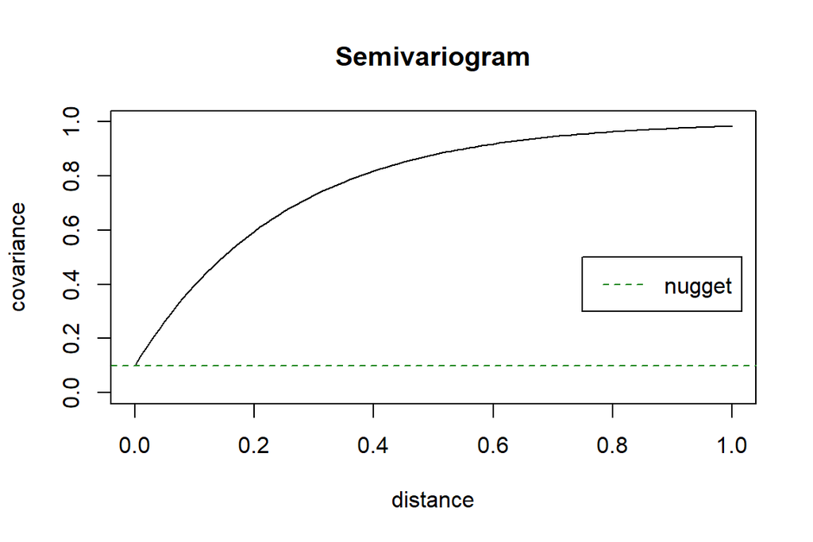

```r
## add in the nugget to make the covariance matrix
  # Note that the "partial sil" is sil - nug in spatial statistics
  # and a semivariogram is just 1 - covariance
curve(1 - ((1-nug)*covar_func(x)), from = 0, to = 1,
      ylab = "covariance", xlab = "distance", main = "Semivariogram",
      ylim = c(0,1))
# add nugget line and legend
abline(h = nug, col = "forestgreen", lty = 2)
legend(x = .75, y = .5, lty = 2, col = "forestgreen", legend = "nugget")
```

The resultant covariance matrix is multiplied by a random variable to obtain the spatial errors ($\delta$). Below are those simulated spatial errors visualized on a heatmap:

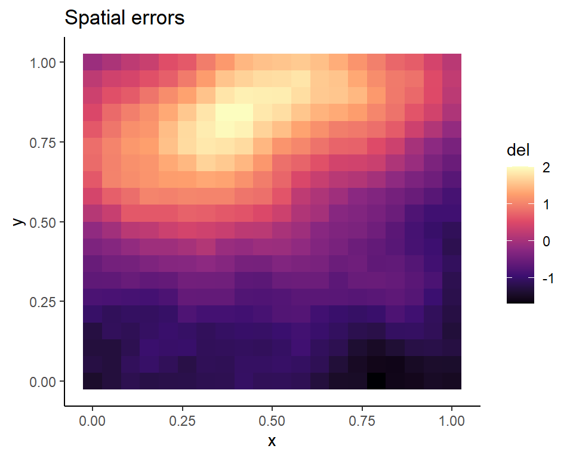

```r
set.seed(2) # set random seed

## Calculate covariance matrix (the nugget is added to the diagonal to get cov(i,i) = nugget)
# Sigma = t(backsolve(chol(nugmat + (1 - nug) * covar_func(D, r)), diag(npix)))
Sigma = nugmat + (1 - nug) * covar_func(D, r)

## Simulate a random spatial error structure
del = scale(Sigma %*% rnorm(npix))

## view the spatial errors
ggplot(data.frame(coords, del), aes(x = x, y = y, fill = del)) +
  geom_tile() + labs(title = "Spatial errors") +
  scale_fill_viridis_c(option = "magma")
```

$\delta$s were then used as the innovation terms for a series of AR simulations to create $\varepsilon(t)$.

```r
set.seed(915)

# 3) Generate spatio-temporal errors (ARMA(1)) using our spatial errors
epsilon = t(rbind(apply(X = t(del), MARGIN = 2,
              function(e){
                arima.sim(n = ntime,
                          model = list(ar = .5, ma = 0, innov = e))
              })))
```

And finally, the fixed effects of time and latitude were added to $\varepsilon$ to create X. Below are the data, separated by time step. The increasing value of $X$ over time and the greater rate of increase at higher latitudes is apparent from this figure. Another thing to note is that the spatial patterns present in $\delta$ are **not** apparent in $X$, though spatial patterns do exist.

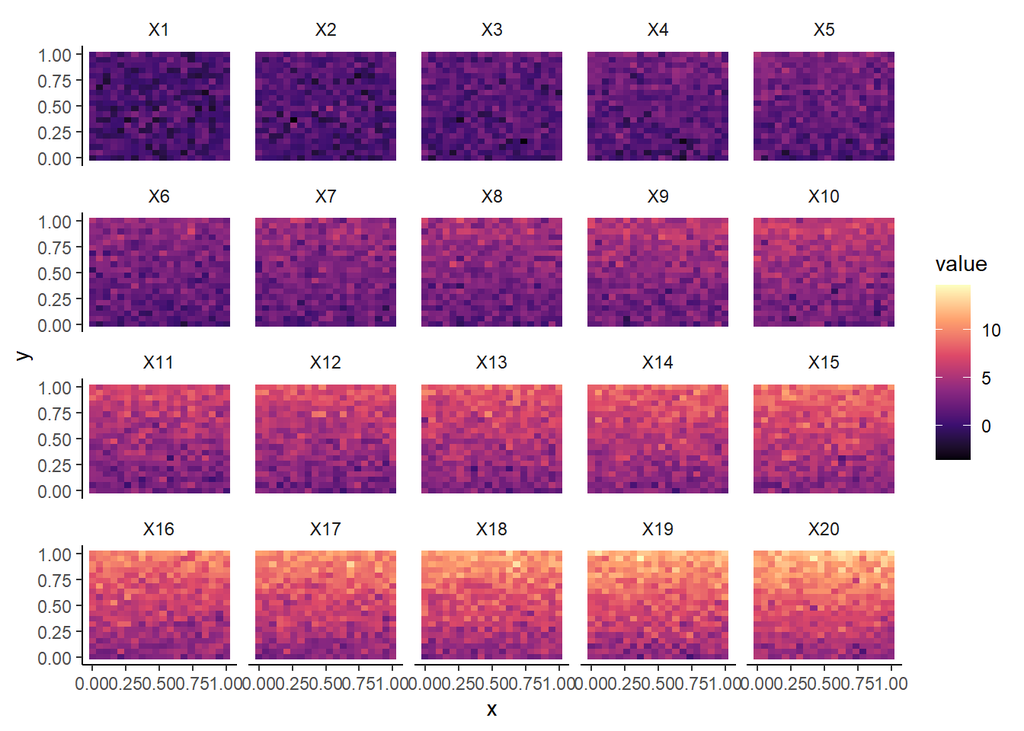

```r
## Add an effect of time plus the spatio-temporal errors

lat.effect = matrix(rep(rep(lambda, npix)*coords[,2], times = ntime), ncol = ntime)
time.int.effect = rep(alpha, npix)
time.lat.effect = rep(beta, npix)*coords[,2]
time.effect = (time.int.effect + time.lat.effect) %*% rbind(1:ntime)

X = lat.effect + time.effect + epsilon

## Add the coordinates back into the data
Xdata = data.frame(coords, X)

## Visualize the simulated data for each time point
Xdata %>% reshape2::melt(id.vars = c("x", "y")) %>%
  # filter(variable == "X1") %>%
  ggplot(aes(x = x, y = y, fill = value)) +
  geom_tile() +
  facet_wrap(~variable) +
  scale_fill_viridis_c(option = "magma")
```

Just to verify, below are figures displaying 1) the average of $X$ at each time step, demonstrating a steady increase; and 2) The average effect of latitude on $X$, again showing a steady increase

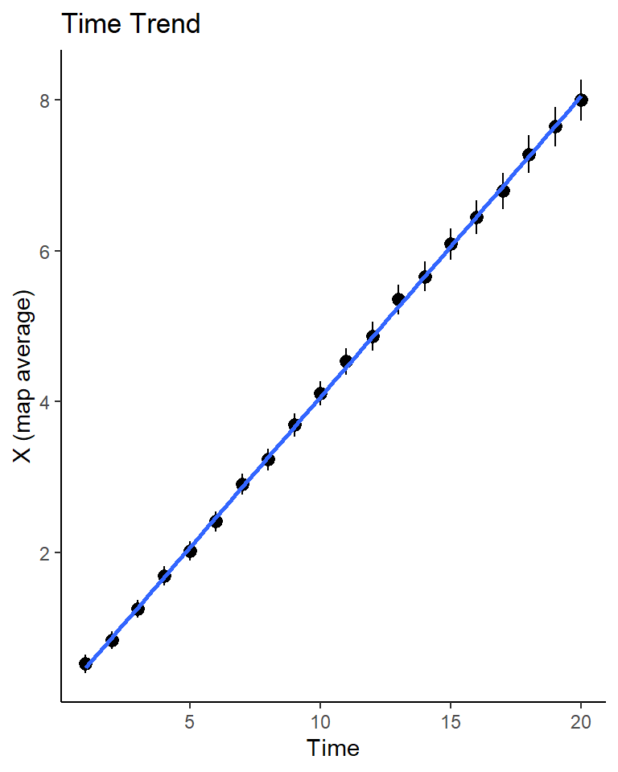

```r
## Visualize the overall time trend
Xdata %>% reshape2::melt(id.vars = c("x", "y")) %>%
  ggplot(aes(x = as.numeric(variable), y = value)) +
  stat_summary(fun.data = "mean_cl_normal") +
  geom_smooth(method = "lm", aes(group = 1), se = FALSE, formula = y ~ x) +
  labs(x = "Time", y = "X (map average)", title = "Time Trend")
```

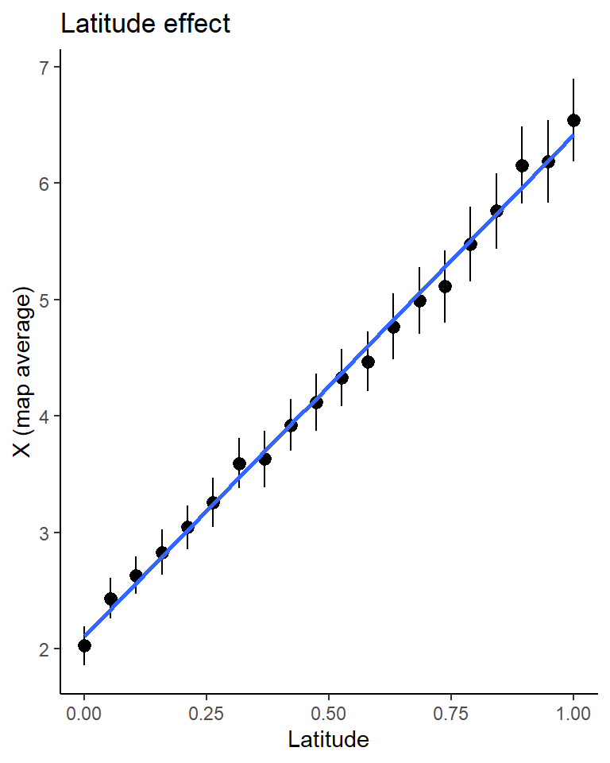

```r
## Visualize the overall effect of latitude
Xdata %>% reshape2::melt(id.vars = c("x", "y")) %>%
  ggplot(aes(x = y, y = value)) +
  stat_summary(fun.data = "mean_cl_normal") +
  geom_smooth(method = "lm", aes(group = 1), se = FALSE, formula = y ~ x) +
  labs(x = "Latitude", y = "X (map average)", title = "Latitude effect")
```

## CLS

Next we fit a CLS (or AR) to the simulated data and plot 1) the spatial distribution of our estimate the time trend; and 2) the effect oflatitude on that time trend.

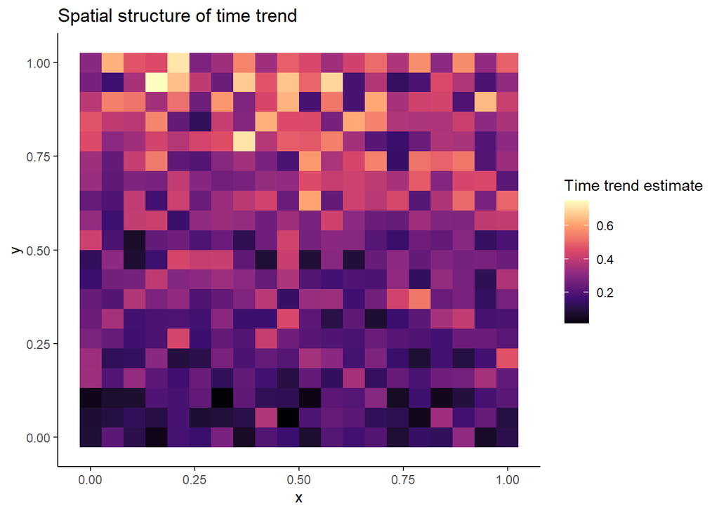

```r
# 4) fit PARTS ----
library(remotePARTS)

## fit CLS
CLS <- fitCLS.map(X, 1:ntime)

## get estimates of alpha and add it back into data
Xdata$alpha.hat = alpha.hat = CLS$time.coef$Est

ggplot(Xdata, aes(x = x, y = y, fill = alpha.hat)) +
  geom_tile() +
  scale_fill_viridis_c(option = "magma") +
  labs(fill = "Time trend estimate", title = "Spatial structure of time trend")
```

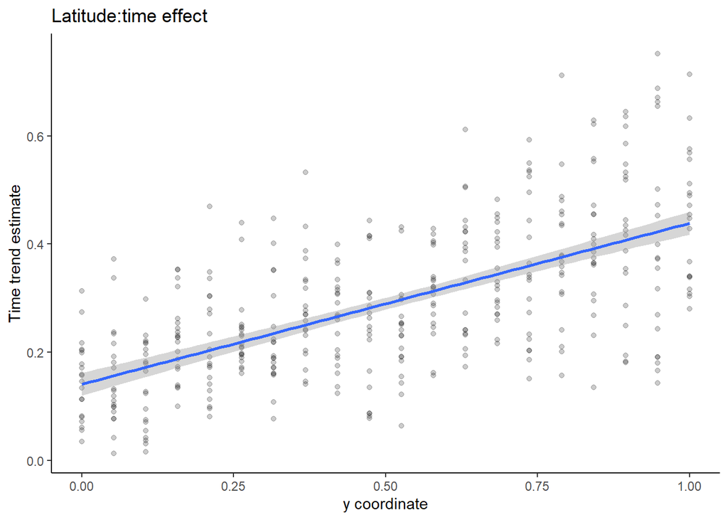

```r
ggplot(Xdata, aes(x = y, y = alpha.hat)) +
  geom_point(alpha = .2) +
  geom_smooth(method = "lm") +
  labs(y = "Time trend estimate", x = "y coordinate", title = "Latitude:time effect")
```

## Estimate range parameter

*Note*: Instead of using `remotePARTS::fit_spatialcor()`, the individual steps are shown in the code block below.

```r
resids = t(CLS$residuals) # matrix of residuals
cor.resids = cor(resids) # corelation matrix of residuals
v.cor.resids = cor.resids[upper.tri(cor.resids, diag = TRUE)] # vector of correlations
v.dist = D[upper.tri(D, diag = TRUE)] # vector of distances

W = data.frame(dist = v.dist, cor = v.cor.resids) # paired dist-cor values

r.est = coef(fit <- nls(cor ~ exp(-dist/r), data = W, start = list(r = 1), trace = FALSE, algorithm = "port"))
r.est
```

```
##           r
## 0.007409365
```

To verify that the estimation method works, we then estimate $r$ from the true covariance matrix. This time, the estimate of $r$ is very close to the true paramter value. **I don’t know what is causing this.**

```r
v.cov.resids = Sigma[upper.tri(Sigma, diag = TRUE)] # vector of true covariance
v.dist = D[upper.tri(D, diag = TRUE)] # vector of distance

W = data.frame(dist = v.dist, cor = v.cov.resids) # paired dist-cov values

coef(fit <- nls(cor ~ exp(-dist/r), data = W, start = list(r = 1), trace = FALSE, algorithm = "port"))
```

```
##         r
## 0.2268346
```

## Estimate nugget

Furthermore, the nugget is not being estimated correctly. Here is the estimate $\eta$ derived from a covariance matrix estimated from the too-small $r$ estimate:

```r
## estimate covariance with r
Sigma.est = covar_func(D, range = r.est)

## estimate nugget with the estimated covariance and alphas
nug.est = optimize_nugget(X = X, V = Sigma.est, y = alpha.hat)
nug.est
```

```
## [1] 0
```

and here it is when using the true covariance matrix.

```r
nug.est2 = optimize_nugget(X, Sigma, alpha.hat)
nug.est2
```

```
## [1] 0.999994
```

**What is going on?**

*Note* I double-checked that these functions are working appropriately by running the Alaska vignette again and everything worked fine in that context.

## GLS

*Note* error bars are standard errors times 1.96 (i.e. pseudo confidence intervals)

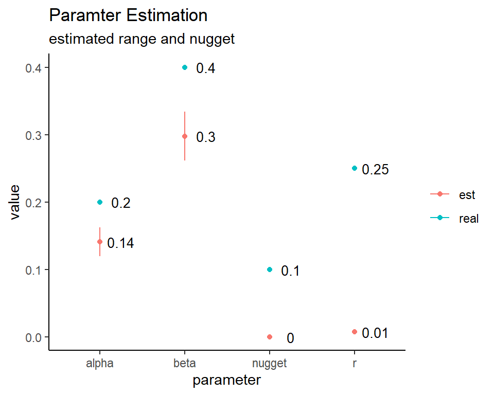

```r
## Fit the GLS
GLS = fitGLS(X = model.matrix(alpha.hat ~ 1 + coords[, 2]), V = Sigma.est,
             y = Xdata$alpha.hat, nugget = nug.est, X0 = rep(1, nrow(X)))
# GLS = fitGLS(X = model.matrix(alpha.hat ~ 1), V = Sigma.est, y = Xdata$alpha.hat, nugget = nug.est, X0 = rep(0, nrow(X)))

est.tab = data.frame(par = c("r", "nugget", "alpha", "beta"),
                     real = c(r, nug, alpha, beta),
                     est = c(r.est, GLS$nugget, GLS$betahat[1], GLS$betahat[2]),
                     SE = c(NA, NA, GLS$SE[1], GLS$SE[2])
                     )

ggplot(est.tab, aes(x = par, y = real)) +
  geom_point(aes(col = "real")) +
  geom_text(aes(,y = real, label = round(real, 2)), nudge_x = .25, nudge_y = 0, size = 3.5) +
  geom_point(aes(y = est, col = "est")) +
  geom_text(aes(,y = est, label = round(est, 2)), nudge_x = .25, nudge_y = 0, size = 3.5) +
  geom_errorbar(aes(y = est, ymin = est - 1.96*SE, ymax = est + 1.96*SE, col = "est"), width = 0) +
  labs(x = "parameter", y = "value", color = NULL, title = "Paramter Estimation", subtitle = "estimated range and nugget")
```

**AND** the estimates don’t change when using the true covariance matrix in the GLS

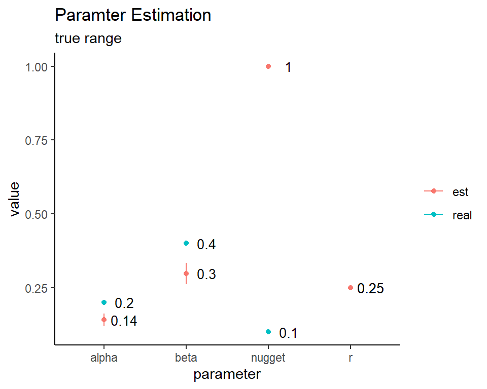

```r
GLS2 = fitGLS(X = model.matrix(alpha.hat ~ 1 + coords[, 2]), V = Sigma,
              y = Xdata$alpha.hat, nugget = nug.est2, X0 = rep(1, nrow(X)))
# GLS = fitGLS(X = model.matrix(alpha.hat ~ 1), V = Sigma.est, y = Xdata$alpha.hat, nugget = nug.est, X0 = rep(0, nrow(X)))

est.tab2 = data.frame(par = c("r", "nugget", "alpha", "beta"),
                     real = c(r, nug, alpha, beta),
                     est = c(r, GLS2$nugget, GLS2$betahat[1], GLS2$betahat[2]),
                     SE = c(NA, NA, GLS2$SE[1], GLS2$SE[2])
                     )

ggplot(est.tab2, aes(x = par, y = real)) +
  geom_point(aes(col = "real")) +
  geom_text(aes(,y = real, label = round(real, 2)), nudge_x = .25, nudge_y = 0, size = 3.5) +
  geom_point(aes(y = est, col = "est")) +
  geom_text(aes(,y = est, label = round(est, 2)), nudge_x = .25, nudge_y = 0, size = 3.5) +
  geom_errorbar(aes(y = est, ymin = est - 1.96*SE, ymax = est + 1.96*SE, col = "est"), width = 0) +
  labs(x = "parameter", y = "value", color = NULL, title = "Paramter Estimation", subtitle = "true range")
```

Finally, when the true covariance matrix and the true nugget are both used, the estimates change but the standard errors become much larger:

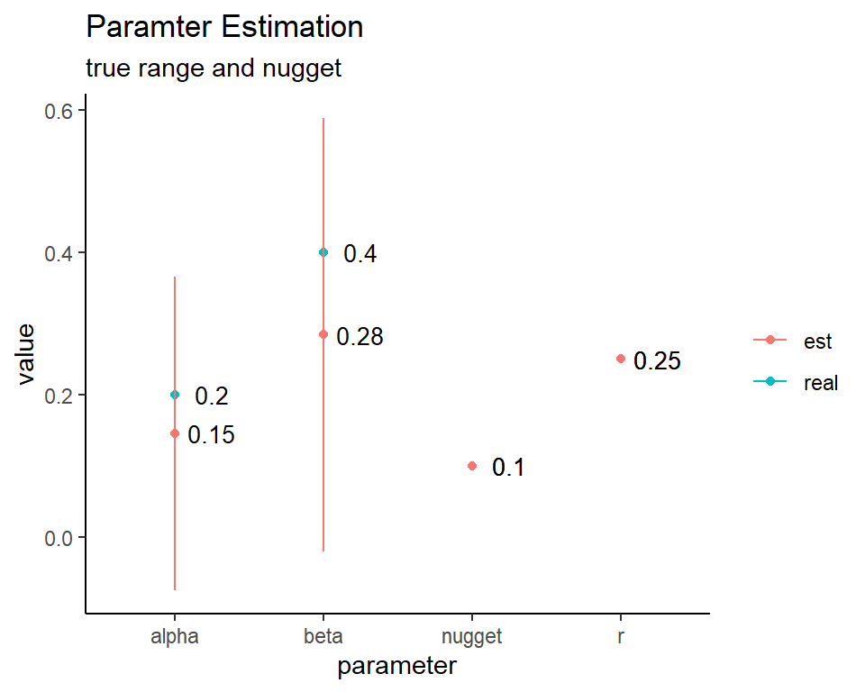

```r
GLS3 = fitGLS(X = model.matrix(alpha.hat ~ 1 + coords[, 2]), V = Sigma,
              y = Xdata$alpha.hat, nugget = nug, X0 = rep(1, nrow(X)))
# GLS = fitGLS(X = model.matrix(alpha.hat ~ 1), V = Sigma.est, y = Xdata$alpha.hat, nugget = nug.est, X0 = rep(0, nrow(X)))

est.tab3 = data.frame(par = c("r", "nugget", "alpha", "beta"),
                     real = c(r, nug, alpha, beta),
                     est = c(r, GLS3$nugget, GLS3$betahat[1], GLS3$betahat[2]),
                     SE = c(NA, NA, GLS3$SE[1], GLS3$SE[2])
                     )

ggplot(est.tab3, aes(x = par, y = real)) +
  geom_point(aes(col = "real")) +
  geom_text(aes(,y = real, label = round(real, 2)), nudge_x = .25, nudge_y = 0, size = 3.5) +
  geom_point(aes(y = est, col = "est")) +
  geom_text(aes(,y = est, label = round(est, 2)), nudge_x = .25, nudge_y = 0, size = 3.5) +
  geom_errorbar(aes(y = est, ymin = est - 1.96*SE, ymax = est + 1.96*SE, col = "est"), width = 0) +
  labs(x = "parameter", y = "value", color = NULL, title = "Paramter Estimation", subtitle = "true range and nugget")
```

```r
## Now fit it again, this time estimating r and nug simultaneously from the data
# This version estimates r and the nugget from the correlations among the alpha estimates instead of residuals
GLS_optim <- optimize_GLS(alpha.hat ~ 1 + y, D = D, data = Xdata, lower = 0, upper = 1)
# GLS_optim <- optimize_GLS(alpha.hat ~ 1, D = D, data = Xdata)
# GLS_optim

est.tab_optim = data.frame(par = c("r", "nugget", "alpha", "beta"),
                     real = c(r, nug, alpha, beta),
                     est = c(NA, GLS_optim$nugget, GLS_optim$betahat[1], GLS_optim$betahat[2]),
                     SE = c(NA, NA, GLS_optim$SE[1], GLS_optim$SE[2])
                     )

# ## add in these estimates to the table
# est.tab$gls.optim = c(NA, GLS_optim$nugget, unname(GLS_optim$betahat)[1], unname(GLS_optim$betahat[2]))

## Even though our estimates of the nugget and range parameter are not very close to the true values,
## the paramter that we're actually interested in (alpha) is! and that's what is important.

ggplot(est.tab_optim, aes(x = par, y = real)) +
  geom_point(aes(col = "real")) +
  geom_point(aes(y = est, col = "est")) +
  labs(x = "parameter", y = "value", color = NULL, title = "Paramter Estimation")
```

[output not shown]